# Théorie des jeux et économie industrielle

Simon Jean

simon.jean@agroparistech.fr

AgroParisTech - CIRED - PSAE

# I. Rappel des concepts importants

## Rappels et outline

- Types de solutions :
  - Fonctions de meilleure réponse
  - Détermination des stratégies dominantes/dominées
  - Induction à rebours

Aujourd’hui, le programme:

- Jeux simultanés : équilibre de Nash, forme normale
- Jeux séquentiels :
- Jeux répétés :
- Duopoles: cas d’étude

# I. Jeux simultanés

## Entreprises polluantes et régulation

- Ecrivez le jeu en forme normale

|  | Firme 2: Investir | Firme 2: Continuer |
| --- | --- | --- |
| Firme 1:Investir | (3,3) | (4,1.5) |
| Firme 1: Continuer | (1.5,4) | (2,2) |

## Entreprises polluantes et régulation

- Quels sont les choix de l’entreprise B?

|  | Firme 2: Investir | Firme 2: Continuer |
| --- | --- | --- |
| Firme 1:Investir | (3,3) | (4,1.5) |
| Firme 1: Continuer | (1.5,4) | (2,2) |

|  | Firme 2: Investir | Firme 2: Continuer |
| --- | --- | --- |
| Firme 1:Investir | (3,3) | (4,1.5) |
| Firme 1: Continuer | (1.5,4) | (2,2) |

## Entreprises polluantes et régulation

- Quels sont les choix de l’entreprise A?

|  | Firme 2: Investir | Firme 2: Continuer |
| --- | --- | --- |
| Firme 1:Investir | (3,3) | (4,1.5) |
| Firme 1: Continuer | (1.5,4) | (2,2) |

|  | Firme 2: Investir | Firme 2: Continuer |
| --- | --- | --- |
| Firme 1:Investir | (3,3) | (4,1.5) |
| Firme 1: Continuer | (1.5,4) | (2,2) |

## Entreprises polluantes et régulation

On a donc les stratégies dominantes suivantes :

|  | Firme 2: Investir | Firme 2: Continuer |
| --- | --- | --- |
| Firme 1:Investir | (3,3) | (4,1.5) |
| Firme 1: Continuer | (1.5,4) | (2,2) |

## Dumping environmental

Le Brésil et l’Union Européenne essaient de former un accord bilatéral pour des standards environnementaux de production. Chacun ont deux options:

- Appliquer des standards élevés : cela implique des normes environnementales coûteuses, mais qui réduisent les pollutions
- Applique des standards bas : les coûts demeurent bas, mais la pollution est plus importante
- Payoffs :
  - Si les deux mettent des standards élevés, les coûts sont importants mais la pollution est limitée: $(4,4)$
  - Si le Brésil applique des standards élevés, mais pas l’UE, la pollution se répend, n’est pas très limitée, les coûts sont élevés $(-1,0)$
  - Si les deux optent pour des standards bas, pollution importante mais coûts limités: $(1,1)$

## Dumping environmental

- Représentez le jeu en forme normale

|  | Stratégie du Brésil Standards élevés (C) | Stratégie du Brésil Standards Faibles (D) |
| --- | --- | --- |
| Standards élevés(C) | (4,4) | (0,-1) |
| Standards Faibles (D) | (-1,0) | (1,1) |

## Dumping environmental

- Où sont le(s) équilibre(s) de Nash?

|  | Stratégies du Brésil Brésil: Standards élevés (C) | Stratégies du Brésil Brésil: Standards faibles (D) |
| --- | --- | --- |
| Standards élevés (C) | (4,4) | (0,-1) |
| Standards faibles (D) | (-1,0) | (1,1) |

- Pas de stratégie dominante
- Mais 2 équilibres de Nash :
  - On a du mal à “choisir”

# Jeux séquentiels

## Jeux séquentiels 1

Prenez deux firmes Alpha et Beta, qui enchérissent de façon récursive pour l’obtention d’une licence d’exploitation. La firme A décide en premier, et la firme B réagit. Le jeu consiste en 3 rounds:

- Round 1 : Alpha décide :
  - Enchère basee : passer au tour suivant
  - Enchère haute : A gagne d’un coup : $A,B = (4,1)$
- Round 2 : décision de Beta si Alpha a choisi une faible enchère
  - Enchère basse : passer au tour suivant
  - Enchère haute : Beta gagne le contrat avec $A,B= (1,4)$
- Round 3 : décision finale de Alpha, si les deux enchères d’avant étaient basses
  - Enchère basse : personne ne gagne et $A,B=(0,0)$
  - Enchère haute : Alpha gagne mais doit partager avec Beta le contrat, $A,B=(3,2)$

## Jeux séquentiels 1

Quel(s) est/sont le(s) équilibre(s) de Nash?

- *(Elevée)* au Round 1
- *(Basse, Elevée)* au Round 2
- *(Basse, Basse, Elevée)* au round 3

## Jeux séquentiels 1

Utilisez *l’induction à rebours* pour trouver les équilibre(s) parfait(s) en sous-jeux

- Au round 3 : A choisira de miser *haut*, donc le payoff est de $(3,2)$
- Au round 2 : B peut choisir entre $(3,2)$ (en misant bas) et $(1,4)$  
  Il choisit donc $(1,4)$ et joue (haut)
- Au round 1 : A sait que B jouera (haut) donc il a le choix entre $(1,4)$ et $(4,1)$  
  [Il choisit donc (haut)]

## Jeux séquentiels 2 - Les pirates

On va résoudre le **jeu des pirates** :

- On a 5 pirates, notés de A à E, par ordre de force
- Ils arrivent sur une île déserte, et y trouvent 100 pièces d’or
- Le plus fort des pirates propose une répartition des pièces entre les pirates :
  - Si une majorité stricte est contre, on le tue  
    Le pirate suivant propose une répartition
  - Sinon, la répartition est adoptée  
    Le jeu est terminé
- On suppose qu’ils sont :
  - **rationnels** : ils veulent maximiser leur nombre de pièces, et préfèrent être pauvres que morts
  - **pas gratuitement cruels** : ils ne choisissent une alternative *que* si elle leur rapporte plus de pièces

## Jeux séquentiels 2 - Les pirates

# Duopole

## Exercice de duopole

On prend encore deux entreprises, A et B. La fonction de demande inverse est $P(Q) = a-bQ$. Les coûts de production sont $CT(q_i)=c_iq_i$

- Exprimez la fonction de profit  
  $\Pi_i(q_i, q_j) = (a - b(q_i+q_j))q_i - c_i q_i$
- A partir de l’équation de profit, trouvez les fonctions de réaction des deux entreprises.

$$\begin{align}
\frac{\partial \Pi_i}{\partial q_i}= a - 2bq_i - bq_j - c &= 0\\
&\Rightarrow q_i(q_j) &= \frac{a - c_i - bq_j}{2b}
\end{align}$$

## Exercice de duopole

- Déterminez le point d’équilibre du duopole, ainsi que les profits des deux entreprises

$$\begin{align}
q_A &= \frac{a-c_A}{3}\\
q_B &= \frac{a-c_A}{3}
\end{align}$$

- Déterminez le prix d’équilibre et le profit de chaque entreprise en supposant que $c_A = c_B = c$

$$\begin{align}
p = \frac{a+c}{3}\\
\Pi = \frac{(a-c)^2}{9}
\end{align}$$

## Exercice de duopole

Maintenant, supposez que l’entreprise $A$ est leader, et la firme $B$ est suiveuse. Comment trouver l’équilibre?

- Premièrement, on peut reprendre la même fonction de réaction et l’intégrer dans le profit de l’entreprise $A$:

$$\Pi_A = \left(a -c - b \left( q_A + \frac{a-c-bq_A}{2b }\right)\right)q_A$$

- On peut donc trouver la quantité qui maximise le profit :
  $$\begin{align}
  \Pi_A' = 0 \iff \left(a -c - \left(2bq_A + b\frac{a - c - 2bq_A}{2b}\right)\right) &= 0\\
  \Rightarrow q_A &= \frac{a-c}{2b}
  \end{align}$$
- Et en déduire la quantité produite par B

$$q_B = \frac{a-c}{4b}$$

## Exercice de duopole

On peut comparer les quantités et profits avec $a= 10$, $b=1$, $c=2$

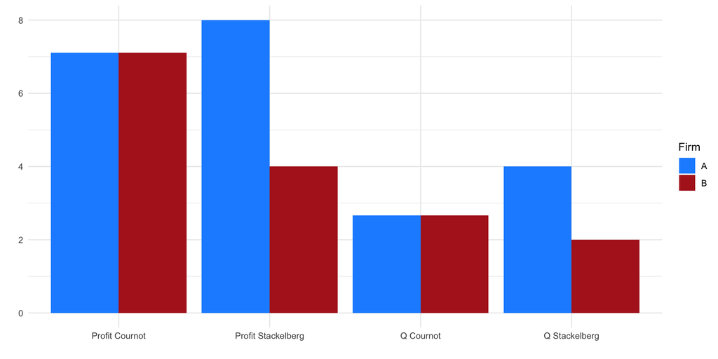

## Collusion

Les deux firmes ont-elles intérêt à opérer une collusion?

- Si la moitié du profit de monopole est supérieur au profit de concurrence en Cournot
- Quel est le profit de monopole?
  $$Pi = (a-c-bQ)Q$$
- Quelle est la production optimale?
  $$a-c-2bQ=0 \Rightarrow Q = \frac{a-c}{2b}$$
- Quel est le niveau de profit?
  $$P=\frac{a+c}{2} \Rightarrow \Pi = \frac{(a-c)^2}{4}$$
- Donc le profit individiuel de chaque firme est :
  $$\Pi_A = \Pi_B = \frac{(a-c)^2}{8}>\frac{(a-c)^2}{9}$$